# A cursory view on linear models

Michele Gubian

March 2022

# Ordinary linear models

## The simplest model

Let us (pretend to) have data from an EMA experiment. A speaker pronounces vowels.

- $x_i$ is the position of tongue dorsum in the $x$ direction of the sagittal plane
- $y_i$ is the corresponding F2
- $i$ is the running index

```
## # A tibble: 10 x 2
##        x     y
##    <dbl> <dbl>
##  1  41.3 1223.
##  2  46.4 1441.
##  3  42.9 1434.
##  4  54.2 1831.
##  5  42.1 1374.
##  6  40.0 1305.
##  7  32.6  785.
##  8  31.1  945.
##  9  33.9  954.
## 10  60.0 1918.
```

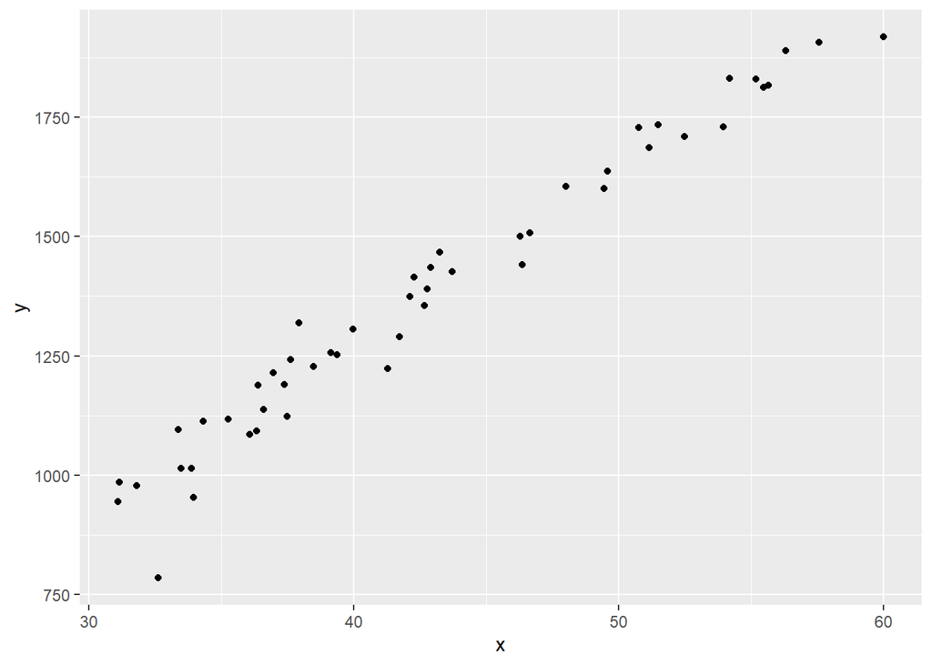

```r
ggplot(D) +
  aes(x, y) +
  geom_point()
```

A linear model has the form:
$$y_i = \beta_0 + \beta_1 \cdot x_i + \epsilon_i$$

- The data are the $x_i$ and the $y_i$
- The linear relationship linking the data is $y_i = \beta_0 + \beta_1 x_i$
- $\epsilon_i$ allows for unknown effects, preserving linearity
- this is a strong hypothesis on the way **unknown** or **not understood** interact with the known ones $x$ and $y$
- **Estimation** means to find suitable, credible values for $\beta_0$ and $\beta_1$
- **Interpreting** the model means to consider the role of $\beta_0$ and $\beta_1$
- e.g. for a unit increase in $x$ we have a variation of $\beta_1$ in $y$ (in the appropriate units)

## What about Gaussianity?

- What is Gaussian in a linear model?
- Does linearity imply Gaussianity?

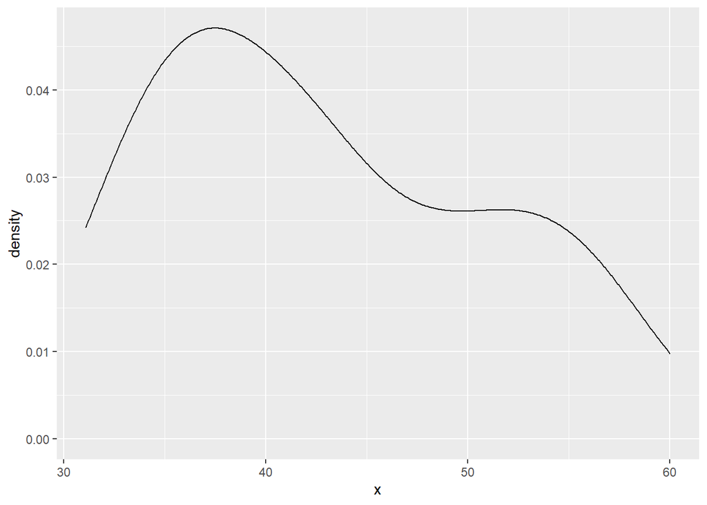

```r
ggplot(D) +
  aes(x) +
  geom_density()
```

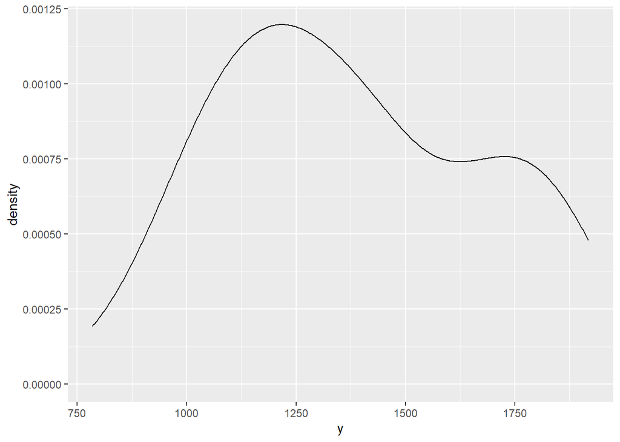

```r
ggplot(D) +
  aes(y) +
  geom_density()
```

- What is Gaussian is $\epsilon$
- $\epsilon_i$ are $N(0, \sigma^2)$ and *independent from each other* and have the same distribution (i.i.d.)
  - this is usually unreasonable, yet of great utitlity in simplifying calculations
  - keep an eye on independence, as this will be violated by GAMMs
- As a consequence, $y_i \sim N(\beta_0 + \beta_1 x_i, \sigma^2)$
- and the estimates of $\beta_0$ and $\beta_1$ are Gaussian too
  - This allows to build confidence intervals for them
- Does linearity imply Gaussianity?
  - No
  - The estimation of $\beta_0$ and $\beta_1$ does not require Gaussianity
  - We like Gaussianity because it allows to build confidence intervals for $\beta_0$ and $\beta_1$

## Linear models in R

So let's do this in R:

```r
lm1 <- lm(y ~ x, data = D)
summary(lm1)
```

```
##
## Call:
## lm(formula = y ~ x, data = D)
##
## Residuals:
##      Min       1Q   Median       3Q      Max
## -218.968  -23.697    5.518   38.399  121.893
##
## Coefficients:
##              Estimate Std. Error t value Pr(>|t|)
## (Intercept) -185.9817    43.0248  -4.323 7.73e-05 ***
## x             36.4727     0.9863  36.979  < 2e-16 ***
## ---
## Signif. codes:  0 '***' 0.001 '**' 0.01 '*' 0.05 '.' 0.1 ' ' 1
##
## Residual standard error: 55.95 on 48 degrees of freedom
## Multiple R-squared:  0.9661, Adjusted R-squared:  0.9654
## F-statistic:  1367 on 1 and 48 DF,  p-value: < 2.2e-16
```

- The *real* formula is $y_i = \beta_0 + \beta_1 x_i + \epsilon_i$
- y ~ x is the so-called "R formula" notation, NOT an equation
- Residuals are the estimated $\epsilon_i$
- (Intercept) is $\beta_0$, x is (confusingly) $\beta_1$
- p-values are there thanks to the Gaussianity hypothesis on $\epsilon_i$
- R-squared measures how much of the variance of $y_i$ is explained by $y_i = \beta_0 + \beta_1 x_i$
  - will come back to this with LMER

The linear model looks like this:

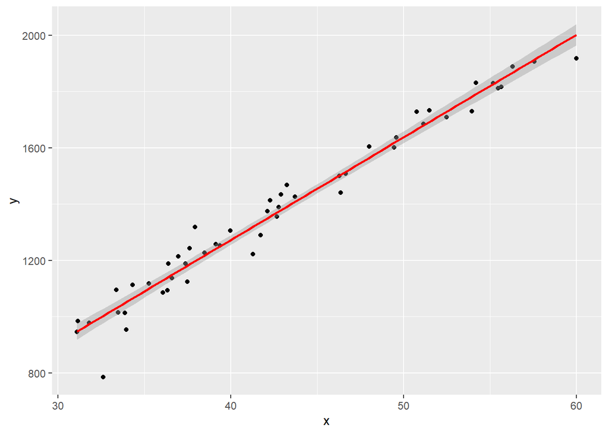

... and it looks like a line, hence the term "linear". In fact:

- $\beta_0$ is the intercept of the line on the $y$ axis
- $\beta_1$ is the line slope

However:

- The terms intercept and slope are used also in settings where they are more confusing than helpful
  - e.g. with factors (see below)

Check if the assumptions on $\epsilon$ are sensible:

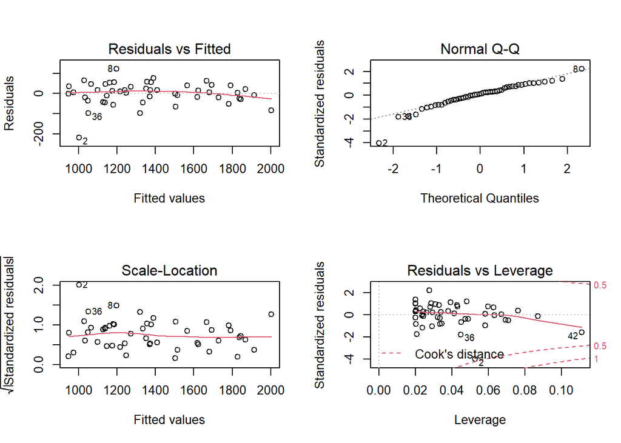

```r
op <- par(mfrow=c(2,2))
plot(lm1)
```

```r
par(op)
```

## Causality

Remember that a linear model detects correlation, not causation.

E.g. take the previous data and model it `the wrong way around'

```r
lm1inv <- lm(x ~ y, data = D)
lm1inv %>% summary
```

```
##
## Call:
## lm(formula = x ~ y, data = D)
##
## Residuals:
##     Min      1Q  Median      3Q     Max
## -3.3966 -0.8545 -0.1720  0.8173  5.4521
##
## Coefficients:
##              Estimate Std. Error t value Pr(>|t|)
## (Intercept) 6.3803546  1.0097549   6.319 8.16e-08 ***
## y           0.0264880  0.0007163  36.979  < 2e-16 ***
## ---
## Signif. codes:  0 '***' 0.001 '**' 0.01 '*' 0.05 '.' 0.1 ' ' 1
##
## Residual standard error: 1.508 on 48 degrees of freedom
## Multiple R-squared:  0.9661, Adjusted R-squared:  0.9654
## F-statistic:  1367 on 1 and 48 DF,  p-value: < 2.2e-16
```

## Non-linear relationships

What if the relation between $x$ and $y$ is non-linear? Can we still use a linear model?

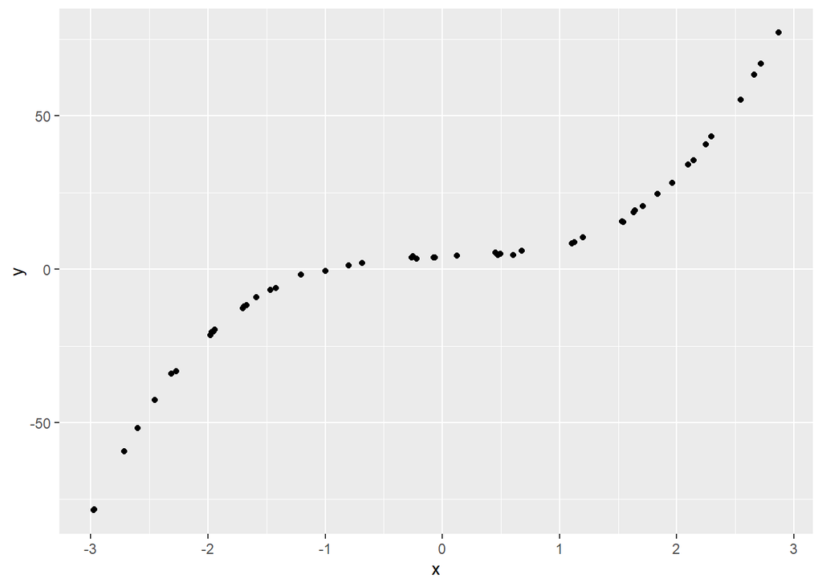

Yes, e.g.:

$$y_i = \beta_0 + \beta_1 \cdot x_i + \beta_2 \cdot x_i^2 + \beta_3 \cdot x_i^3 + \epsilon_i$$
is linear in the $\beta$'s, i.e. the $\beta$'s only appear in sums or in multiplications with known quantities (the $x_i$'s)

```r
lm2 <- lm(y ~ x + I(x^2) + I(x^3), data = D)
summary(lm2)
```

```
##
## Call:
## lm(formula = y ~ x + I(x^2) + I(x^3), data = D)
##
## Residuals:
##      Min       1Q   Median       3Q      Max
## -1.04026 -0.33884 -0.00578  0.30342  1.38479
##
## Coefficients:
##              Estimate Std. Error t value Pr(>|t|)
## (Intercept)  3.970692   0.103024  38.541  < 2e-16 ***
## x            0.831040   0.091597   9.073 8.18e-12 ***
## I(x^2)      -0.009142   0.025540  -0.358    0.722
## I(x^3)       3.026898   0.016012 189.039  < 2e-16 ***
## ---
## Signif. codes:  0 '***' 0.001 '**' 0.01 '*' 0.05 '.' 0.1 ' ' 1
##
## Residual standard error: 0.4615 on 46 degrees of freedom
## Multiple R-squared:  0.9998, Adjusted R-squared:  0.9998
## F-statistic: 8.077e+04 on 3 and 46 DF,  p-value: < 2.2e-16
```

Note that this is 'kind of' a GAM.

The basic idea of GAM is to be able to determine automatically how many terms like $\beta_2 x_i^2$ to include in the model, as opposed to guess or try.

## Model selection

The previous data set could have been modelled also by:
$$y_i = \beta_0 + \beta_1 \cdot x_i + \beta_3 \cdot x_i^3 + \epsilon_i$$
How to decide in general what's the best model?

- **Model selection** is basically finding the simplest model consistent with a set of data
- There are automated procedures based on information criteria

```r
step(lm2)
```

```
## Start:  AIC=-73.49
## y ~ x + I(x^2) + I(x^3)
##
##          Df Sum of Sq    RSS     AIC
## - I(x^2)  1       0.0    9.8 -75.347
## <none>                   9.8 -73.487
## - x       1      17.5   27.3 -24.194
## - I(x^3)  1    7612.6 7622.4 257.341
##
## Step:  AIC=-75.35
## y ~ x + I(x^3)
##
##          Df Sum of Sq    RSS     AIC
## <none>                   9.8 -75.347
## - x       1      17.5   27.3 -26.167
## - I(x^3)  1    7707.2 7717.0 255.958
```

```
##
## Call:
## lm(formula = y ~ x + I(x^3), data = D)
##
## Coefficients:
## (Intercept)            x       I(x^3)
##      3.9422       0.8288       3.0275
```

- But it is not always advisable to blindly rely on those procedures
  - e.g. you may have good reasons to keep a predictor based on previous solid evidence
  - or end up with too many variables just because you have a lot of data, which would hinder interpretability

## Factors

Example:

- $x_i$ is the vowel, e.g. /a/, /i/, /o/, /u/
- $y_i$ is the corresponding F2

Now $x$ is a categorical variable, or factor. How do we make it into a number?

```
## # A tibble: 6 x 2
##   x         y
##   <fct> <dbl>
## 1 a     1304.
## 2 a     1204.
## 3 a     1116.
## 4 a     1214.
## 5 a     1151.
## 6 a     1227.
```

```r
lm3 <- lm(y ~ x, data = D)
summary(lm3)
```

```
##
## Call:
## lm(formula = y ~ x, data = D)
##
## Residuals:
##     Min      1Q  Median      3Q     Max
## -317.35  -67.62    3.93   64.73  287.12
##
## Coefficients:
##             Estimate Std. Error t value Pr(>|t|)
## (Intercept)  1216.89      14.68   82.87   <2e-16 ***
## xi           1077.89      20.77   51.91   <2e-16 ***
## xo           -310.34      20.77  -14.94   <2e-16 ***
## xu           -291.36      20.77  -14.03   <2e-16 ***
## ---
## Signif. codes:  0 '***' 0.001 '**' 0.01 '*' 0.05 '.' 0.1 ' ' 1
##
## Residual standard error: 103.8 on 196 degrees of freedom
## Multiple R-squared:  0.9682, Adjusted R-squared:  0.9677
## F-statistic:  1989 on 3 and 196 DF,  p-value: < 2.2e-16
```

The real equation looks like:
$$y_i = \beta_{/a/} + \beta_{/i/} \cdot I(x_i = /i/) + \beta_{/o/} \cdot I(x_i = /o/) + \beta_{/u/} \cdot I(x_i = /u/) + \epsilon_i$$

- lm() created indicator (or dummy) variables, i.e. taking values 0 or 1 on a logical statement
- they are 3, i.e. one minus the number of categories (factor levels)
- The intercept models the fourth left-out level, here /a/
  - if we had 4 indicators + intercept the equation would not be identifiable
  - R picks the first level in alphabetic order as intercept

Typical questions you want to answer using a factorial experiment

- What's the expected (mean) F2 frequency for /i/?
- Are the F2 values of /o/ and /u/ distinguishable?

Can we answer these questions from the summary?

- What's the expected (mean) F2 frequency for /i/?
  - $\beta_{/a/} + \beta_{/i/}$, i.e. Estimate of (Intercept) + Estimate of xi
- Are the F2 values of /o/ and /u/ distinguishable (significantly different)?
  - we cannot tell from the summary
  - we can only answer this question on pairs /a/ vs. another vowel
  - for the other pairs we need to compute post tests, or use contrasts
- Fortunately, all this mess is taken care of by the `emmeans` R library

```r
emmeans(lm3, pairwise ~ x)
```

```
## $emmeans
##  x emmean   SE  df lower.CL upper.CL
##  a   1217 14.7 196     1188     1246
##  i   2295 14.7 196     2266     2324
##  o    907 14.7 196      878      936
##  u    926 14.7 196      897      954
##
## Confidence level used: 0.95
##
## $contrasts
##  contrast estimate   SE  df t.ratio p.value
##  a - i       -1078 20.8 196 -51.905  <.0001
##  a - o         310 20.8 196  14.944  <.0001
##  a - u         291 20.8 196  14.030  <.0001
##  i - o        1388 20.8 196  66.850  <.0001
##  i - u        1369 20.8 196  65.936  <.0001
##  o - u         -19 20.8 196  -0.914  0.7973
##
## P value adjustment: tukey method for comparing a family of 4 estimates
```

## Interactions between factors

Let's add gender to the vowels example

```r
D %>% sample_n(2)
```

```
## # A tibble: 16 x 3
## # Groups:   x, g [8]
##    x     g         y
##    <chr> <chr> <dbl>
##  1 a     F     1425.
##  2 a     F     1377.
##  3 a     M     1201.
##  4 a     M     1285.
##  5 i     F     2967.
##  6 i     F     2947.
##  7 i     M     2259.
##  8 i     M     2318.
##  9 o     F      991.
## 10 o     F      948.
## 11 o     M      912.
## 12 o     M      957.
## 13 u     F      991.
## 14 u     F      924.
## 15 u     M      890.
## 16 u     M      826.
```

```r
lm4 <- lm(y ~ x + g, data = D)
summary(lm4)
```

```
##
## Call:
## lm(formula = y ~ x + g, data = D)
##
## Residuals:
##     Min      1Q  Median      3Q     Max
## -296.89  -97.44    5.26   95.65  368.26
##
## Coefficients:
##             Estimate Std. Error t value Pr(>|t|)
## (Intercept)  1413.91      15.09   93.73   <2e-16 ***
## xi           1319.42      19.08   69.15   <2e-16 ***
## xo           -349.34      19.08  -18.31   <2e-16 ***
## xu           -371.89      19.08  -19.49   <2e-16 ***
## gM           -232.73      13.49  -17.25   <2e-16 ***
## ---
## Signif. codes:  0 '***' 0.001 '**' 0.01 '*' 0.05 '.' 0.1 ' ' 1
##
## Residual standard error: 134.9 on 395 degrees of freedom
## Multiple R-squared:  0.9647, Adjusted R-squared:  0.9644
## F-statistic:  2700 on 4 and 395 DF,  p-value: < 2.2e-16
```

```r
emmeans(lm4, pairwise ~ g | x)
```

```
## $emmeans
## x = a:
##  g emmean   SE  df lower.CL upper.CL
##  F   1414 15.1 395     1384     1444
##  M   1181 15.1 395     1152     1211
##
## x = i:
##  g emmean   SE  df lower.CL upper.CL
##  F   2733 15.1 395     2704     2763
##  M   2501 15.1 395     2471     2530
##
## x = o:
##  g emmean   SE  df lower.CL upper.CL
##  F   1065 15.1 395     1035     1094
##  M    832 15.1 395      802      861
##
## x = u:
##  g emmean   SE  df lower.CL upper.CL
##  F   1042 15.1 395     1012     1072
##  M    809 15.1 395      780      839
##
## Confidence level used: 0.95
##
## $contrasts
## x = a:
##  contrast estimate   SE  df t.ratio p.value
##  F - M         233 13.5 395  17.249  <.0001
##
## x = i:
##  contrast estimate   SE  df t.ratio p.value
##  F - M         233 13.5 395  17.249  <.0001
##
## x = o:
##  contrast estimate   SE  df t.ratio p.value
##  F - M         233 13.5 395  17.249  <.0001
##
## x = u:
##  contrast estimate   SE  df t.ratio p.value
##  F - M         233 13.5 395  17.249  <.0001
```

- The gender factor adds the same quantity to any vowel
- Conversely, the /i/ factor adds the same quantity to male and female
- What if e.g. females' /i/ has an even higher value than the one obtained adding the respective /i/ and female effects?

```r
lm4.1 <- lm(y ~ x * g, data = D)
summary(lm4.1)
```

```
##
## Call:
## lm(formula = y ~ x * g, data = D)
##
## Residuals:
##      Min       1Q   Median       3Q      Max
## -130.567  -30.076   -0.533   30.227  157.258
##
## Coefficients:
##             Estimate Std. Error t value Pr(>|t|)
## (Intercept) 1394.445      6.650  209.69   <2e-16 ***
## xi          1549.880      9.405  164.80   <2e-16 ***
## xo          -426.387      9.405  -45.34   <2e-16 ***
## xu          -447.446      9.405  -47.58   <2e-16 ***
## gM          -193.805      9.405  -20.61   <2e-16 ***
## xi:gM       -460.926     13.300  -34.66   <2e-16 ***
## xo:gM        154.102     13.300   11.59   <2e-16 ***
## xu:gM        151.104     13.300   11.36   <2e-16 ***
## ---
## Signif. codes:  0 '***' 0.001 '**' 0.01 '*' 0.05 '.' 0.1 ' ' 1
##
## Residual standard error: 47.02 on 392 degrees of freedom
## Multiple R-squared:  0.9957, Adjusted R-squared:  0.9957
## F-statistic: 1.311e+04 on 7 and 392 DF,  p-value: < 2.2e-16
```

```r
emmeans(lm4.1, pairwise ~ g | x)
```

```
## $emmeans
## x = a:
##  g emmean   SE  df lower.CL upper.CL
##  F 1394.4 6.65 392   1381.4   1407.5
##  M 1200.6 6.65 392   1187.6   1213.7
##
## x = i:
##  g emmean   SE  df lower.CL upper.CL
##  F 2944.3 6.65 392   2931.3   2957.4
##  M 2289.6 6.65 392   2276.5   2302.7
##
## x = o:
##  g emmean   SE  df lower.CL upper.CL
##  F  968.1 6.65 392    955.0    981.1
##  M  928.4 6.65 392    915.3    941.4
##
## x = u:
##  g emmean   SE  df lower.CL upper.CL
##  F  947.0 6.65 392    933.9    960.1
##  M  904.3 6.65 392    891.2    917.4
##
## Confidence level used: 0.95
##
## $contrasts
## x = a:
##  contrast estimate  SE  df t.ratio p.value
##  F - M       193.8 9.4 392  20.608  <.0001
##
## x = i:
##  contrast estimate  SE  df t.ratio p.value
##  F - M       654.7 9.4 392  69.618  <.0001
##
## x = o:
##  contrast estimate  SE  df t.ratio p.value
##  F - M        39.7 9.4 392   4.222  <.0001
##
## x = u:
##  contrast estimate  SE  df t.ratio p.value
##  F - M        42.7 9.4 392   4.540  <.0001
```

# Linear Mixed Effects Models

Let's have many subjects pronounce a vowel many times with or witout a certain condition $x$ We measure F1 in the middle of each vowel.

- $x = 0$ condition absent, $x = 1$ condition present
- $y$ is F1

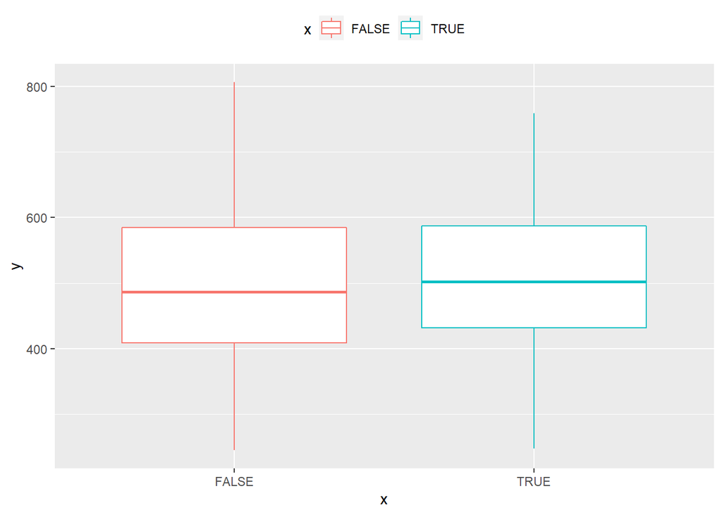

```r
ggplot(D) + aes(x, y, color = x) + geom_boxplot() + theme(legend.position="top")
```

```r
lm(y ~ x, data = D) %>% summary
```

```
##
## Call:
## lm(formula = y ~ x, data = D)
##
## Residuals:
##      Min       1Q   Median       3Q      Max
## -259.687  -81.572   -6.104   82.665  312.226
##
## Coefficients:
##             Estimate Std. Error t value Pr(>|t|)
## (Intercept)  494.165      6.223  79.405   <2e-16 ***
## xTRUE         13.503      8.801   1.534    0.125
## ---
## Signif. codes:  0 '***' 0.001 '**' 0.01 '*' 0.05 '.' 0.1 ' ' 1
##
## Residual standard error: 107.8 on 598 degrees of freedom
## Multiple R-squared:  0.003921,   Adjusted R-squared:  0.002255
## F-statistic: 2.354 on 1 and 598 DF,  p-value: 0.1255
```

Actually the data look like this when taking subjects ($z$) into account:

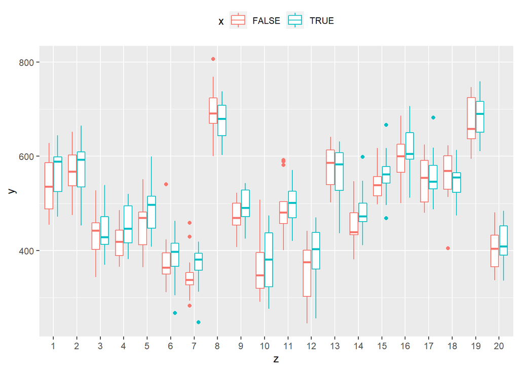

```r
ggplot(D) + aes(z, y, color = x) + geom_boxplot() + theme(legend.position="top")
```

How can we take this into account in a linear model?

```r
lm(y ~ x + z, data = D)
```

This means that we have one indicator variable per subject, $z_1, z_2$, etc. But each new experiment will have different subjects, so $z_1$ does not mean anything in general.

In other words, knowing something about subjects 1 to 20 does not tell us anything about subject 21, as there are no constraints on them.

We want to **add structure to the noise**, i.e.

- there are two sources of noise
- one is the particular way subjects differ from one another
- another is the particular way each utterance is produced
- with all this, we want to preserve linearity

The maths goes like this:

$$y_{i, j} = \beta_0 + \beta_1 \cdot x_{i, j} + u_i + \epsilon_{i, j} \\
u_i \sim N(0, \sigma_u) \\
\epsilon_{i, j} \sim N(0, \sigma) \\
u_i, \epsilon_{i, j} \; \text{ indipendent of each other}$$
where $i$ is the subject index, $j$ is the utterance index within $i$.

**Note on terminology:** the factor `x` is called **fixed**, while the speaker factor `z` is called **random**. The term random refers to the fact that the levels of `z` are by design a random extraction from a much larger population of possible levels (speakers in this case). Random does not mean that the effect of this factor on the model will be random, erratic or anything like that.

Setting a factor as 'random' in a LMER simply means that we are constraining it to behave in a certain way, namely that its additive effect follows a zero-centered Gaussian distribution. In other words, we are hypothesising that these levels all belong to a distribution. If we add one more level, e.g. one more speaker, we already expect that its effect will be within a certain distribution, that its behaviour is unlikely to be completely different from the other speakers. This is a general practice known as *regularisation*, a strategy to get robust estimations. In practice, one can, and sometimes has to use it also outside the typical setting that gave random effects their name. For example, when the number of levels is high, say 10 or 20, even though these are all the levels there are, e.g. all the letters of the alphabet, and no random extraction from a larger set was made. In that case, it will be close to impossible to obtain reliable estimates if we set this factor as fixed. The only viable option is to set it as random, which only means that we are applying some constraints on it. Unfortunately, this also means that it is not possible to apply `emmeans` to those levels, i.e. no post-hoc tests.

In R with package lme4:

```r
lmer1 <- lmer(y ~ x + (1|z), data = D)
summary(lmer1)
```

```
## Linear mixed model fit by REML ['lmerMod']
## Formula: y ~ x + (1 | z)
##    Data: D
##
## REML criterion at convergence: 6481.8
##
## Scaled residuals:
##     Min      1Q  Median      3Q     Max
## -2.8114 -0.6758  0.0080  0.6937  3.2517
##
## Random effects:
##  Groups   Name        Variance Std.Dev.
##  z        (Intercept) 9547     97.71
##  Residual             2519     50.19
## Number of obs: 600, groups:  z, 20
##
## Fixed effects:
##             Estimate Std. Error t value
## (Intercept)  494.165     22.040  22.422
## xTRUE         13.503      4.098   3.295
##
## Correlation of Fixed Effects:
##       (Intr)
## xTRUE -0.093
```

```r
emmeans(lmer1, pairwise ~ x)
```

```
## $emmeans
##  x     emmean SE   df lower.CL upper.CL
##  FALSE    494 22 19.3      448      540
##   TRUE    508 22 19.3      462      554
##
## Degrees-of-freedom method: kenward-roger
## Confidence level used: 0.95
##
## $contrasts
##  contrast     estimate  SE  df t.ratio p.value
##  FALSE - TRUE    -13.5 4.1 579  -3.295  0.0010
##
## Degrees-of-freedom method: kenward-roger
```

## More structure on noise: random slopes

We want add the following information to the random component of the model:

- different subjects have a global level that varies
  - i.e. random intercept, we've got it already, that's $u_i$
- different subjects perform the contrast $x$ differently, i.e. some more, some less on average
  - that's called a random slope (which is not a helpful name in this case)
- possibly, random intercepts and slopes are correlated
  - e.g. the higher than average subjects are, the less prominently they produce the contrast $x$

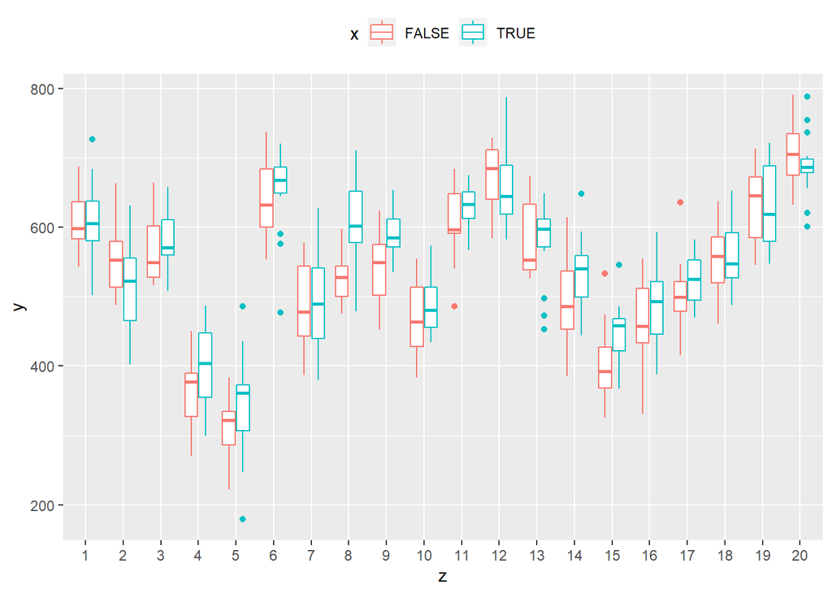

The R formula notation to express the random effect structure is: `(x|z)`. It is a short for `(1 + x|z)`, which says it incorporates both random intercept and slope. It is *not* the same as `(1 |z) + (0 + x|z)`, because the latter specifies a random elements structure where random intercept and slope are not correlated, while with `(1 + x|z)` we also get an estimate of their correlation.

```r
lmer1 <- lmer(y ~ x + (x|z), data = D)
lmer1 %>% summary
```

```
## Linear mixed model fit by REML ['lmerMod']
## Formula: y ~ x + (x | z)
##    Data: D
##
## REML criterion at convergence: 6554.1
##
## Scaled residuals:
##     Min      1Q  Median      3Q     Max
## -3.2525 -0.6856 -0.0378  0.6642  2.6344
##
## Random effects:
##  Groups   Name        Variance Std.Dev. Corr
##  z        (Intercept) 10268    101.33
##           xTRUE         378     19.44   -0.66
##  Residual              2812     53.03
## Number of obs: 600, groups:  z, 20
##
## Fixed effects:
##             Estimate Std. Error t value
## (Intercept)  534.626     22.864   23.38
## xTRUE         16.443      6.136    2.68
##
## Correlation of Fixed Effects:
##       (Intr)
## xTRUE -0.533
```

```r
emmeans(lmer1, pairwise ~ x)
```

```
## $emmeans
##  x     emmean   SE df lower.CL upper.CL
##  FALSE    535 22.9 19      487      582
##   TRUE    551 20.3 19      509      593
##
## Degrees-of-freedom method: kenward-roger
## Confidence level used: 0.95
##
## $contrasts
##  contrast     estimate   SE df t.ratio p.value
##  FALSE - TRUE    -16.4 6.14 19  -2.680  0.0148
##
## Degrees-of-freedom method: kenward-roger
```

The estimate of the correlation between random intercept and slope (row `xTRUE`, column `Corr` under `Random effects`) confirms that they are negatively correlated.

## Inspecting random effects

Just like you can look (plot) the residuals in a lm, you can look at the random intercepts and slopes:

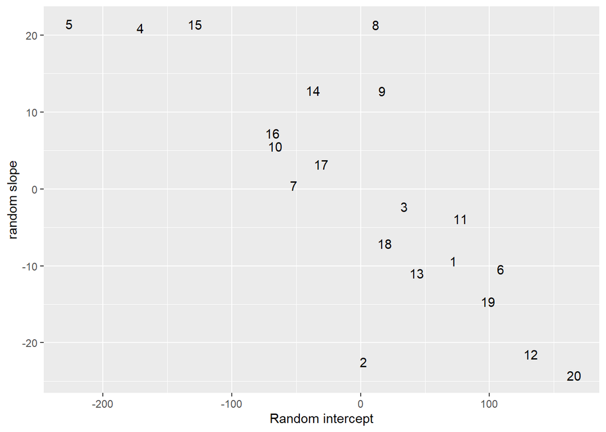

```r
lmer1.ranef <- lmer1 %>% ranef() %>% .$z %>% as_tibble() %>% rownames_to_column("Subject")
ggplot(lmer1.ranef) +
  aes(`(Intercept)`, xTRUE, label = Subject) +
  geom_text() +
  xlab("Random intercept") +
  ylab("random slope")
```

## Proportion of explained variance ($R^2$)

There is no straightforward way to get $R^2$ like for lm(). An estimate has been proposed, **Pseudo-R-squared**, which allows to get info on proportion of variance explained by fixed and random factors.

- Marginal $R^2$: proportion of variance explained by fixed effects
- Conditional $R^2$: proportion of variance explained by fixed and random effects combined
  - i.e. all except $\epsilon$

```r
library(MuMIn)
r.squaredGLMM(lmer1)
```

```
##            R2m       R2c
## [1,] 0.0056288 0.7661978
```

E.g. useful to have an idea of how large is the inter-subject variation compared to the general (fixed) effect under investigation.

# Multiresponse models

Suppose we want to predict the value of both F1 and F2 for each given vowel. Can we do this?

Short answer:

- If there are no random effects: yes
- If there are random effects: more no than yes

## No random effects

Example:

- $x_i$ is the vowel, e.g. /a/, /i/, /o/, /u/
- $F1_i$ and $F2_i$ are the corresponding first two formats

The equation looks like this:
$$F1_i = \beta_{F1, /a/} + \beta_{F1, /i/} \cdot I(x_i = /i/) + \beta_{F1, /o/} \cdot I(x_i = /o/) + \beta_{F1, /u/} \cdot I(x_i = /u/) + \epsilon_{F1, i} \\
F2_i = \beta_{F2, /a/} + \beta_{F2, /i/} \cdot I(x_i = /i/) + \beta_{F2, /o/} \cdot I(x_i = /o/) + \beta_{F2, /u/} \cdot I(x_i = /u/) + \epsilon_{F2, i}$$
In practice, these are two almost independent models, as all the $\beta$ terms for the two formants are distinct and independent. What links the two models is the fact that the two $\epsilon$ terms are estimated jointly and their correlation is also estimated (i.e. the two $\epsilon$ belong to a two dimensional random variable with Gaussian distribution, zero mean and a general 2-by-2 covariance matrix).

In R, we can use `lm`:

```r
mlm1 <- lm(cbind(F1, F2) ~ x, data = D)
summary(mlm1)
```

```
## Response F1 :
##
## Call:
## lm(formula = F1 ~ x, data = D)
##
## Residuals:
##      Min       1Q   Median       3Q      Max
## -270.881  -62.898   -2.042   71.908  270.346
##
## Coefficients:
##             Estimate Std. Error t value Pr(>|t|)
## (Intercept)   798.62      14.41   55.43   <2e-16 ***
## xi           -524.21      20.38  -25.73   <2e-16 ***
## xo           -344.82      20.38  -16.92   <2e-16 ***
## xu           -394.78      20.38  -19.38   <2e-16 ***
## ---
## Signif. codes:  0 '***' 0.001 '**' 0.01 '*' 0.05 '.' 0.1 ' ' 1
##
## Residual standard error: 101.9 on 196 degrees of freedom
## Multiple R-squared:  0.7869, Adjusted R-squared:  0.7836
## F-statistic: 241.3 on 3 and 196 DF,  p-value: < 2.2e-16
##
##
## Response F2 :
##
## Call:
## lm(formula = F2 ~ x, data = D)
##
## Residuals:
##      Min       1Q   Median       3Q      Max
## -276.092  -62.231    6.834   54.920  293.075
##
## Coefficients:
##             Estimate Std. Error t value Pr(>|t|)
## (Intercept)  1208.99      13.55   89.21   <2e-16 ***
## xi           1075.07      19.17   56.09   <2e-16 ***
## xo           -263.70      19.17  -13.76   <2e-16 ***
## xu           -317.48      19.17  -16.57   <2e-16 ***
## ---
## Signif. codes:  0 '***' 0.001 '**' 0.01 '*' 0.05 '.' 0.1 ' ' 1
##
## Residual standard error: 95.83 on 196 degrees of freedom
## Multiple R-squared:  0.9723, Adjusted R-squared:  0.9719
## F-statistic:  2296 on 3 and 196 DF,  p-value: < 2.2e-16
```

```r
emmeans(mlm1, pairwise ~ x | formant, mult.name = "formant")
```

```
## $emmeans
## formant = F1:
##  x emmean   SE  df lower.CL upper.CL
##  a    799 14.4 196      770      827
##  i    274 14.4 196      246      303
##  o    454 14.4 196      425      482
##  u    404 14.4 196      375      432
##
## formant = F2:
##  x emmean   SE  df lower.CL upper.CL
##  a   1209 13.6 196     1182     1236
##  i   2284 13.6 196     2257     2311
##  o    945 13.6 196      919      972
##  u    892 13.6 196      865      918
##
## Confidence level used: 0.95
##
## $contrasts
## formant = F1:
##  contrast estimate   SE  df t.ratio p.value
##  a - i       524.2 20.4 196  25.727  <.0001
##  a - o       344.8 20.4 196  16.923  <.0001
##  a - u       394.8 20.4 196  19.375  <.0001
##  i - o      -179.4 20.4 196  -8.804  <.0001
##  i - u      -129.4 20.4 196  -6.352  <.0001
##  o - u        50.0 20.4 196   2.452  0.0710
##
## formant = F2:
##  contrast estimate   SE  df t.ratio p.value
##  a - i     -1075.1 19.2 196 -56.095  <.0001
##  a - o       263.7 19.2 196  13.760  <.0001
##  a - u       317.5 19.2 196  16.566  <.0001
##  i - o      1338.8 19.2 196  69.855  <.0001
##  i - u      1392.6 19.2 196  72.661  <.0001
##  o - u        53.8 19.2 196   2.806  0.0280
##
## P value adjustment: tukey method for comparing a family of 4 estimates
```

More resources on this:

- [Appendix to "An R Companion to Applied Regression" by Fox & Weisberg](https://socialsciences.mcmaster.ca/jfox/Books/Companion/appendices/Appendix-Multivariate-Linear-Models.pdf)
- [Post by University of Virginia](https://data.library.virginia.edu/getting-started-with-multivariate-multiple-regression/)

## Multiresponse LMER

There are two directions I would try, one is frequentist, the other Bayesian.

- Frequentist: R library `mcglm`. It is quite rich and you can do basically everything **except** post-hoc comparisons. It does not interface with `emmeans`, nor there is any indication that such tests will be available in the future (see [this post by Bonat](https://stats.stackexchange.com/questions/363921/pairwise-comparisons-on-mcglm-joint-model-in-r))
- Bayesian: using R library `brms`, which is based on the *Stan* engine, it is possible to define and estimate multiresponse LMERs. But Bayesian methods are beyond the scope of these notes